# Tutorial 3

Smoothing and Forecasting in Financial Time Series

Author

Barry Quinn

Published

February 13, 2025

# 1 Introduction

In this tutorial, you’ll learn to:

1. Retrieve and preprocess financial time-series data.
2. Apply smoothing techniques: Moving Averages, Savitzky-Golay, Lowess, and Kalman filter.
3. Fit an ARIMA model for forecasting, understanding its limitations.

Why Smoothing?

- Financial data is noisy with frequent fluctuations.
- Smoothing removes short-term noise and highlights trends.
- However, no smoothing method guarantees profitable signals in efficient markets.

Why Forecasting?

- Financial price forecasting is difficult due to the random-walk hypothesis.
- ARIMA is a useful time-series modelling technique.

# 2 Data Setup

## 2.1 Retrieve AAPL data

```r
getSymbols("AAPL", from = "2020-01-01", to = "2022-12-31", auto.assign = TRUE)
```

```
[1] "AAPL"
```

```r
aapl_prices <- Cl(AAPL)

# View data
head(aapl_prices)
```

```
           AAPL.Close
2020-01-02    75.0875
2020-01-03    74.3575
2020-01-06    74.9500
2020-01-07    74.5975
2020-01-08    75.7975
2020-01-09    77.4075
```

## 2.3 Convert to tibble for ggplot

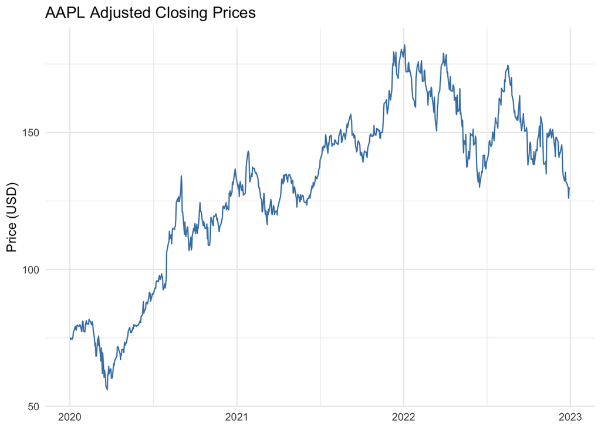

```r
aapl_df <- tibble(
  date  = index(aapl_prices),
  price = as.numeric(aapl_prices)
)

ggplot(aapl_df, aes(x = date, y = price)) +
  geom_line(color="steelblue") +
  labs(title="AAPL Adjusted Closing Prices", x=NULL, y="Price (USD)") +
  theme_minimal()
```

# 3 Smoothing Methods

## 3.1 Simple Moving Average (SMA)

The Simple Moving Average (SMA) calculates the arithmetic mean of prices over a specified window (n days). Each point gets equal weight (1/n), making it the most basic smoothing technique. While simple, it has two key economic implications: - It treats recent and old prices equally, which may not reflect market efficiency - The lag is approximately (n+1)/2 days, making it a lagging indicator - Commonly used windows are 20 days (monthly), 50 days (quarterly), and 200 days (yearly)

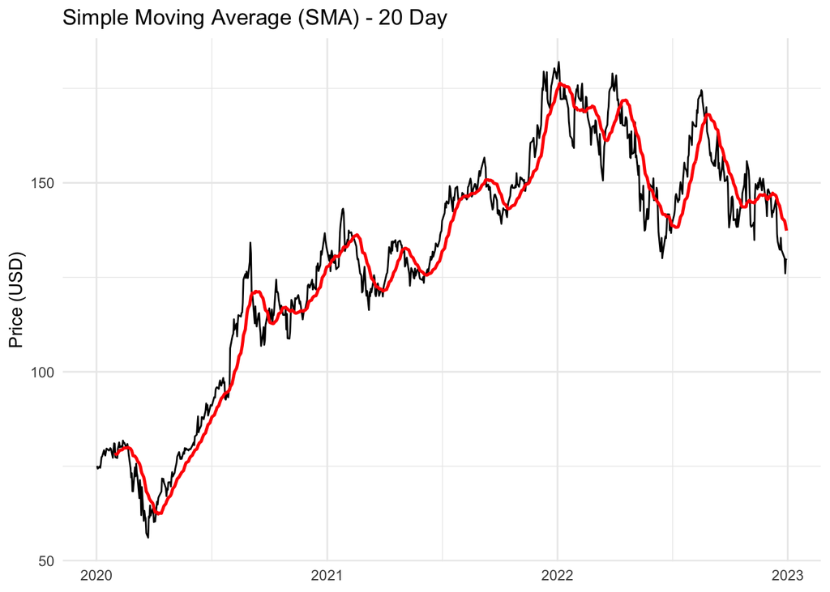

```r
sma_20 <- SMA(aapl_prices, n = 20)

df_sma <- tibble(
  date  = index(aapl_prices),
  price = as.numeric(aapl_prices),
  sma20 = as.numeric(sma_20)
)

ggplot(df_sma, aes(x=date)) +
  geom_line(aes(y=price), color="black") +
  geom_line(aes(y=sma20), color="red", size=0.9) +
  labs(title="Simple Moving Average (SMA) - 20 Day", x=NULL, y="Price (USD)") +
  theme_minimal()
```

> Question: How does the SMA compare in volatility reduction?

## 3.2 Exponential Moving Average (EMA)

The EMA assigns exponentially decreasing weights to older observations, giving more importance to recent prices. The smoothing factor α = 2/(n+1) determines the rate of decay: - More responsive to recent price changes than SMA, better reflecting market efficiency - Reduces lag while maintaining smoothing properties - The effective “memory” of the indicator extends infinitely but with rapidly diminishing weights

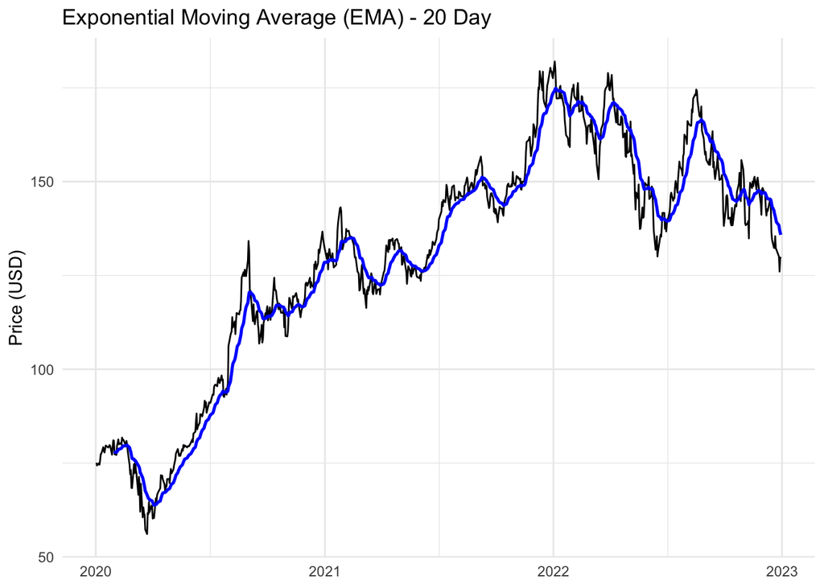

```r
ema_20 <- EMA(aapl_prices, n=20)

df_ema <- tibble(
  date  = index(aapl_prices),
  price = as.numeric(aapl_prices),
  ema20 = as.numeric(ema_20)
)

ggplot(df_ema, aes(x=date)) +
  geom_line(aes(y=price), color="black") +
  geom_line(aes(y=ema20), color="blue", size=0.9) +
  labs(title="Exponential Moving Average (EMA) - 20 Day", x=NULL, y="Price (USD)") +
  theme_minimal()
```

# 4 Exercise: Compare the lag and responsiveness of SMA vs. EMA.

## 4.1 Weighted Moving Average (WMA)

The WMA applies linear weights to prices, with recent observations getting higher weights. Unlike EMA’s exponential decay: - Provides a middle ground between SMA and EMA in terms of responsiveness - Weights typically decline arithmetically (e.g., 5,4,3,2,1) - Has a finite memory determined by the window size - Often used in technical analysis for price momentum studies

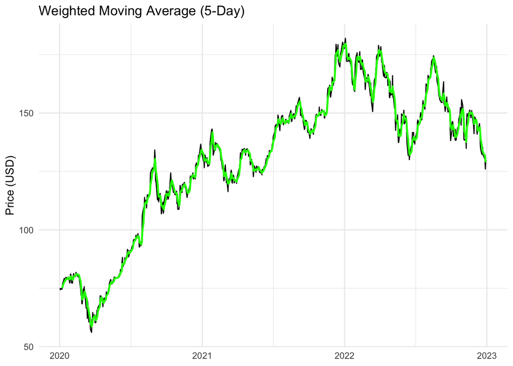

```r
weights <- c(1,2,3,4,5)
weights <- weights/sum(weights)

wma_5 <- WMA(aapl_prices, n=5, wts=weights)

df_wma <- tibble(
  date   = index(aapl_prices),
  price  = as.numeric(aapl_prices),
  wma_5  = as.numeric(wma_5)
)

ggplot(df_wma, aes(x=date)) +
  geom_line(aes(y=price), color="black") +
  geom_line(aes(y=wma_5), color="green", size=0.9) +
  labs(title="Weighted Moving Average (5-Day)", x=NULL, y="Price (USD)") +
  theme_minimal()
```

## 4.2 Savitzky-Golay Filter

The Savitzky-Golay filter fits a polynomial of degree p to n points around each data point using least squares. Unlike moving averages: - Preserves higher moments (peaks, valleys) better than traditional moving averages - Particularly useful for identifying trend reversals in price movements - The polynomial degree p controls smoothness vs. feature preservation - Often used in high-frequency trading for noise reduction

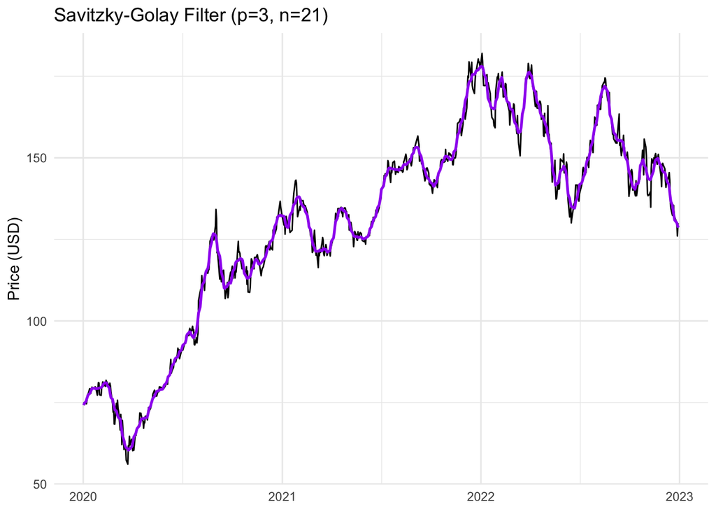

```r
sg_filter <- sgolayfilt(as.numeric(aapl_prices), p=3, n=21)

df_sg <- tibble(
  date  = index(aapl_prices),
  price = as.numeric(aapl_prices),
  sg    = as.numeric(sg_filter)
)

ggplot(df_sg, aes(x=date)) +
  geom_line(aes(y=price), color="black") +
  geom_line(aes(y=sg), color="purple", size=0.9) +
  labs(title="Savitzky-Golay Filter (p=3, n=21)", x=NULL, y="Price (USD)") +
  theme_minimal()
```

## 4.3 Lowess Smoothing

Locally Weighted Scatterplot Smoothing (LOWESS) fits a polynomial regression to local neighborhoods of points: - Adapts to local price volatility better than global smoothers - The bandwidth parameter f controls the size of the local neighborhood - Robust to outliers through iterative reweighting - Particularly useful for identifying long-term market trends while adapting to changing volatility regimes

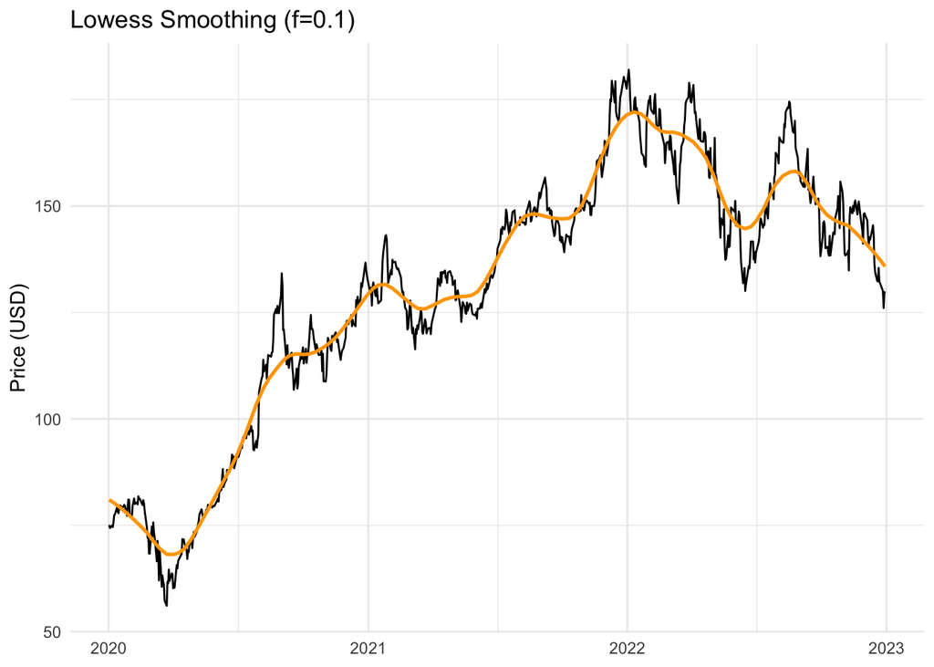

```r
df_lo_in <- tibble(
  x  = as.numeric(index(aapl_prices)),
  y  = as.numeric(aapl_prices)
)

lo_out <- lowess(df_lo_in$x, df_lo_in$y, f=0.1)

df_lo <- tibble(
  date  = as.Date(df_lo_in$x, origin="1970-01-01"),
  price = df_lo_in$y,
  lo    = lo_out$y
)

ggplot(df_lo, aes(x=date)) +
  geom_line(aes(y=price), color="black") +
  geom_line(aes(y=lo), color="orange", size=0.9) +
  labs(title="Lowess Smoothing (f=0.1)", x=NULL, y="Price (USD)") +
  theme_minimal()
```

## 4.4 Kalman Filter

The Kalman filter is a recursive Bayesian estimator that combines a prediction model with noisy measurements: - Optimal for linear systems with Gaussian noise - Adapts dynamically to changing market volatility - Parameters dV (measurement noise) and dW (process noise) control smoothing strength - Particularly useful for real-time trading as it provides both filtered estimates and prediction uncertainties

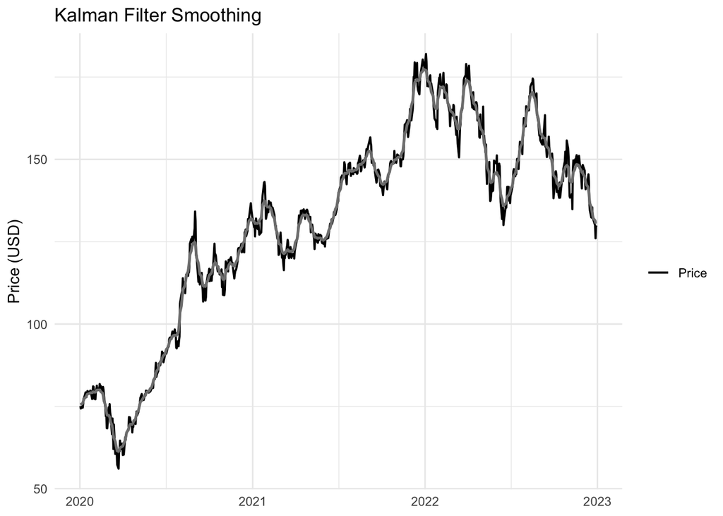

```r
mod_poly <- dlmModPoly(order=1, dV=15100, dW=1470)
kf_smooth <- dlmSmooth(as.numeric(aapl_prices), mod_poly)

df_kf <- tibble(
  date    = index(aapl_prices),
  price   = as.numeric(aapl_prices),
  kalman  = dropFirst(kf_smooth$s)
)

ggplot(df_kf, aes(x=date)) +
  geom_line(aes(y=price, color="Price"), size=0.7) +
  geom_line(aes(y=kalman, color="blue"), size=0.9) +
  labs(title="Kalman Filter Smoothing", x=NULL, y="Price (USD)") +
  scale_color_manual(name="", values=c("Price"="black","Kalman"="blue")) +
  theme_minimal()
```

## 4.5 ARIMA Forecast

ARIMA (Autoregressive Integrated Moving Average) models combine three components: - AR(p): Autoregressive component capturing price dependencies - I(d): Integration/differencing for stationarity - MA(q): Moving average component for error structure

The model is denoted as ARIMA(p,d,q) where: - p: Number of lagged returns affecting current return - d: Number of times we difference prices to achieve stationarity - q: Number of lagged error terms in the model

### 4.5.1 Creating a Time-Series Object

We create a time series object with 252 trading days per year:

```r
aapl_ts <- ts(as.numeric(aapl_prices), frequency = 252, start = c(2020, as.numeric(format(start(aapl_prices), "%j"))))
```

### 4.5.2 ARIMA Model

The auto.arima() function automatically selects optimal p, d, q values by minimizing AIC/BIC: - Tests for stationarity and determines appropriate differencing - Searches over possible AR and MA orders - Includes drift terms if beneficial - Uses maximum likelihood estimation for parameters

```r
fit_arima <- auto.arima(aapl_ts)
summary(fit_arima)
```

```
Series: aapl_ts
ARIMA(0,1,0)

sigma^2 = 7.798:  log likelihood = -1846.63
AIC=3695.26   AICc=3695.26   BIC=3699.88

Training set error measures:
                    ME     RMSE      MAE        MPE     MAPE       MASE
Training set 0.0726423 2.790626 2.074084 0.04565066 1.664307 0.06149399
                    ACF1
Training set -0.06167857
```

### 4.5.3 Forecasting

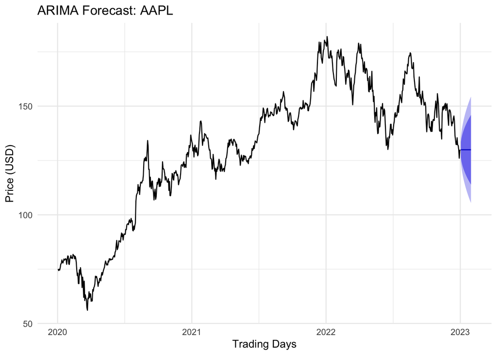

```r
future_fc <- forecast(fit_arima, h=20)

autoplot(future_fc) +
  labs(title="ARIMA Forecast: AAPL", x="Trading Days", y="Price (USD)") +
  theme_minimal()
```

# 5 Exercises

1. Compare smoothing methods:
- Which method is fastest at reacting to sudden price jumps?
- Which is slowest and smoothest?
2. Experiment with ARIMA forecasts:
- Does it revert to a drift term?
- How does adjusting the time window affect the fit?

# 6 Wrap-Up

- Financial prices are noisy; smoothing highlights trends but does not create profitable signals.
- ARIMA models are useful but often resemble random-walk structures.
- Advanced methods (GARCH, ML) may offer better predictive power.